# Exploring Prosper Loan (P2P) by Min Lu

# Introduction:

Prosper is a P2P marketplace providing person-to-person lending utilizing alisting and bidding process to get competitive rates for loans.

In this project, I will use R and data anaylst skills to explore relationships between multiple variables.

# Explore Dataset

```
## 'data.frame':    113937 obs. of  81 variables:
##  $ ListingKey                         : Factor w/ 113066 levels "00003546482094282EF90E5",..: 7180 7193 6647 6669 6686 6689 6699 6706 6687 6687 ...
##  $ ListingNumber                      : int  193129 1209647 81716 658116 909464 1074836 750899 768193 1023355 1023355 ...
##  $ ListingCreationDate                : Factor w/ 113064 levels "2005-11-09 20:44:28.847000000",..: 14184 111894 6429 64760 85967 100310 72556 74019 97834 97834 ...
##  $ CreditGrade                        : Factor w/ 9 levels "","A","AA","B",..: 5 1 8 1 1 1 1 1 1 1 ...
##  $ Term                               : int  36 36 36 36 36 60 36 36 36 36 ...
##  $ LoanStatus                         : Factor w/ 12 levels "Cancelled","Chargedoff",..: 3 4 3 4 4 4 4 4 4 4 ...
##  $ ClosedDate                         : Factor w/ 2803 levels "","2005-11-25 00:00:00",..: 1138 1 1263 1 1 1 1 1 1 1 ...
##  $ BorrowerAPR                        : num  0.165 0.12 0.283 0.125 0.246 ...
##  $ BorrowerRate                       : num  0.158 0.092 0.275 0.0974 0.2085 ...
##  $ LenderYield                        : num  0.138 0.082 0.24 0.0874 0.1985 ...
##  $ EstimatedEffectiveYield            : num  NA 0.0796 NA 0.0849 0.1832 ...
##  $ EstimatedLoss                      : num  NA 0.0249 NA 0.0249 0.0925 ...
##  $ EstimatedReturn                    : num  NA 0.0547 NA 0.06 0.0907 ...
##  $ ProsperRating..numeric.            : int  NA 6 NA 6 3 5 2 4 7 7 ...
```

[output cut: 67 more lines]

```
##  [1] "ListingKey"
##  [2] "ListingNumber"
##  [3] "ListingCreationDate"
##  [4] "CreditGrade"
##  [5] "Term"
##  [6] "LoanStatus"
##  [7] "ClosedDate"
##  [8] "BorrowerAPR"
##  [9] "BorrowerRate"
## [10] "LenderYield"
## [11] "EstimatedEffectiveYield"
## [12] "EstimatedLoss"
## [13] "EstimatedReturn"
## [14] "ProsperRating..numeric."
## [15] "ProsperRating..Alpha."
```

[output cut: 66 more lines]

```
## [1] 113937
```

```
## [1] 81
```

```
##                    ListingKey     ListingNumber
##  17A93590655669644DB4C06:     6   Min.   :      4
##  349D3587495831350F0F648:     4   1st Qu.: 400919
##  47C1359638497431975670B:     4   Median : 600554
##  8474358854651984137201C:     4   Mean   : 627886
##  DE8535960513435199406CE:     4   3rd Qu.: 892634
##  04C13599434217079754AEE:     3   Max.   :1255725
##  (Other)                :113912
##                     ListingCreationDate  CreditGrade         Term
##  2013-10-02 17:20:16.550000000:     6          :84984   Min.   :12.00
##  2013-08-28 20:31:41.107000000:     4   C      : 5649   1st Qu.:36.00
##  2013-09-08 09:27:44.853000000:     4   D      : 5153   Median :36.00
##  2013-12-06 05:43:13.830000000:     4   B      : 4389   Mean   :40.83
##  2013-12-06 11:44:58.283000000:     4   AA     : 3509   3rd Qu.:36.00
##  2013-08-21 07:25:22.360000000:     3   HR     : 3508   Max.   :60.00
##  (Other)                      :113912   (Other): 6745
##                  LoanStatus                  ClosedDate
##  Current              :56576                      :58848
##  Completed            :38074   2014-03-04 00:00:00:  105
##  Chargedoff           :11992   2014-02-19 00:00:00:  100
##  Defaulted            : 5018   2014-02-11 00:00:00:   92
##  Past Due (1-15 days) :  806   2012-10-30 00:00:00:   81
##  Past Due (31-60 days):  363   2013-02-26 00:00:00:   78
##  (Other)              : 1108   (Other)            :54633
##   BorrowerAPR       BorrowerRate     LenderYield
##  Min.   :0.00653   Min.   :0.0000   Min.   :-0.0100
##  1st Qu.:0.15629   1st Qu.:0.1340   1st Qu.: 0.1242
##  Median :0.20976   Median :0.1840   Median : 0.1730
##  Mean   :0.21883   Mean   :0.1928   Mean   : 0.1827
##  3rd Qu.:0.28381   3rd Qu.:0.2500   3rd Qu.: 0.2400
##  Max.   :0.51229   Max.   :0.4975   Max.   : 0.4925
##  NA's   :25
##  EstimatedEffectiveYield EstimatedLoss   EstimatedReturn
##  Min.   :-0.183          Min.   :0.005   Min.   :-0.183
##  1st Qu.: 0.116          1st Qu.:0.042   1st Qu.: 0.074
##  Median : 0.162          Median :0.072   Median : 0.092
##  Mean   : 0.169          Mean   :0.080   Mean   : 0.096
##  3rd Qu.: 0.224          3rd Qu.:0.112   3rd Qu.: 0.117
##  Max.   : 0.320          Max.   :0.366   Max.   : 0.284
##  NA's   :29084           NA's   :29084   NA's   :29084
```

[output cut: 193 more lines]

```
##  Min.   :    0.00                Min.   :0.7000   Min.   : 0.00000
##  1st Qu.:    0.00                1st Qu.:1.0000   1st Qu.: 0.00000
##  Median :    0.00                Median :1.0000   Median : 0.00000
##  Mean   :   25.14                Mean   :0.9986   Mean   : 0.04803
##  3rd Qu.:    0.00                3rd Qu.:1.0000   3rd Qu.: 0.00000
##  Max.   :21117.90                Max.   :1.0125   Max.   :39.00000
##
##  InvestmentFromFriendsCount InvestmentFromFriendsAmount   Investors
##  Min.   : 0.00000           Min.   :    0.00            Min.   :   1.00
##  1st Qu.: 0.00000           1st Qu.:    0.00            1st Qu.:   2.00
##  Median : 0.00000           Median :    0.00            Median :  44.00
##  Mean   : 0.02346           Mean   :   16.55            Mean   :  80.48
##  3rd Qu.: 0.00000           3rd Qu.:    0.00            3rd Qu.: 115.00
##  Max.   :33.00000           Max.   :25000.00            Max.   :1189.00
##
```

# Univariate Plots Section

```
##    Min. 1st Qu.  Median    Mean 3rd Qu.    Max.    NA's
##    1.00    4.00    6.00    5.95    8.00   11.00   29084
```

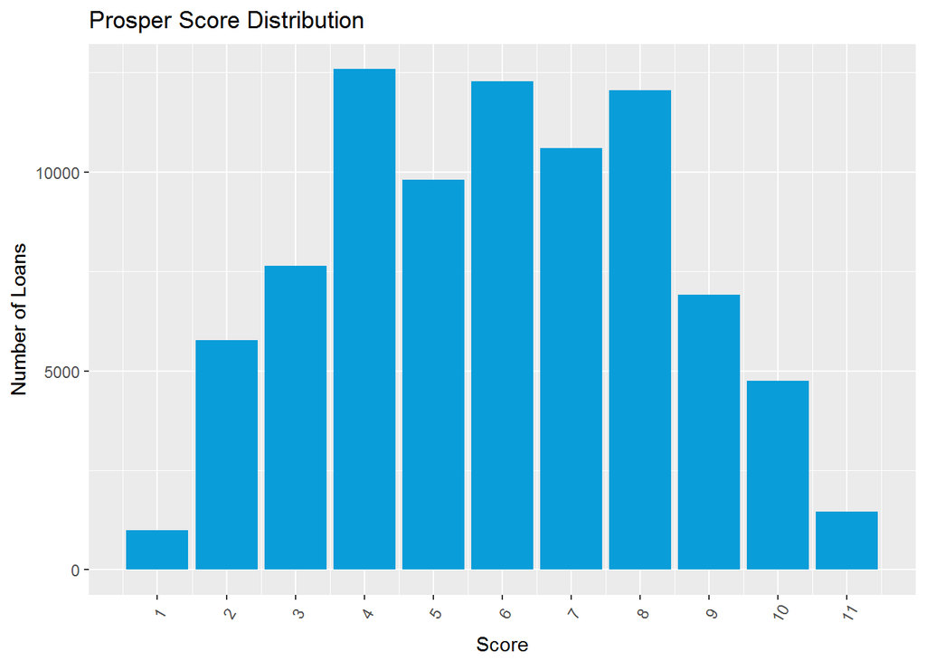

Here we can see a normal distribution chart if we did not count NA. It looks like most loans are under 4-8 score ranges.

```
##           A    AA     B     C     D     E    HR
## 29084 14551  5372 15581 18345 14274  9795  6935
```

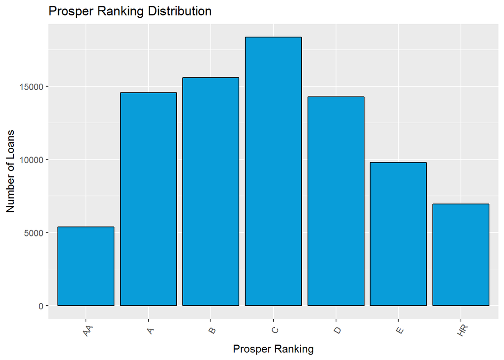

From the chart above, the majority of loan are being rated as “A”,“B”,“c” and “D”.

```
##             $0      $1-24,999 $25,000-49,999 $50,000-74,999 $75,000-99,999
##            621           7274          32192          31050          16916
##      $100,000+   Not employed  Not displayed
##          17337            806           7741
```

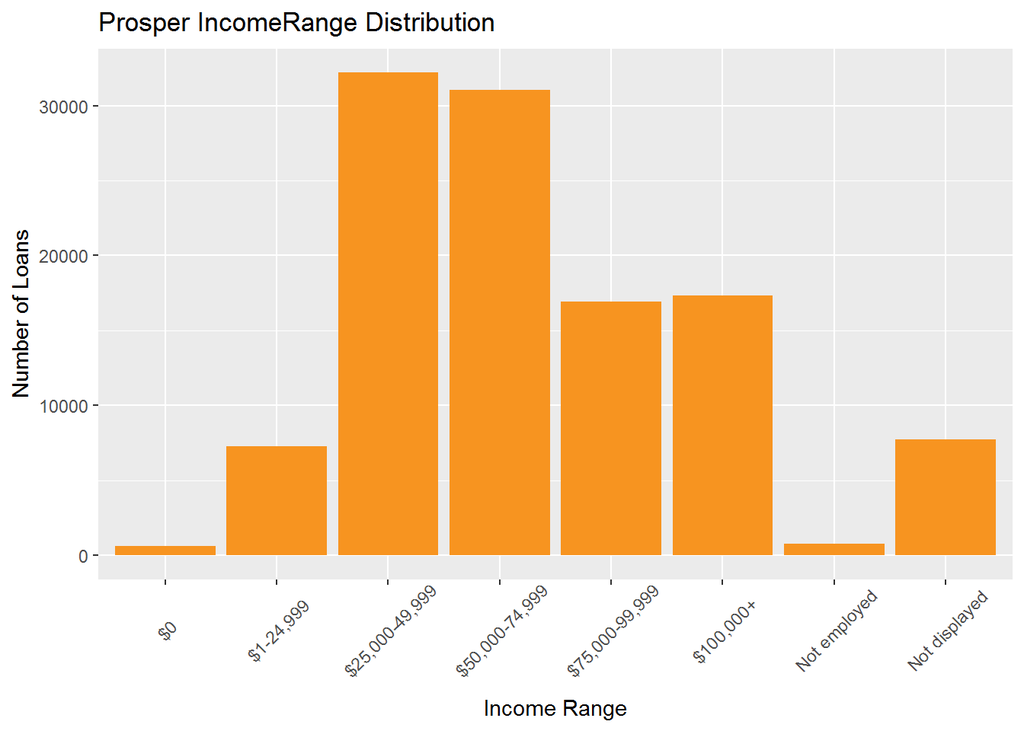

People from income range 25,000-49,999 and 50,000-74,999 are the main borrower.However, people with income under 25000 are not major borrower. So, probably Prosper.com has some income limits on borrowers or Prosper.com main target are future home-owners or car-owners, but not for student loan.

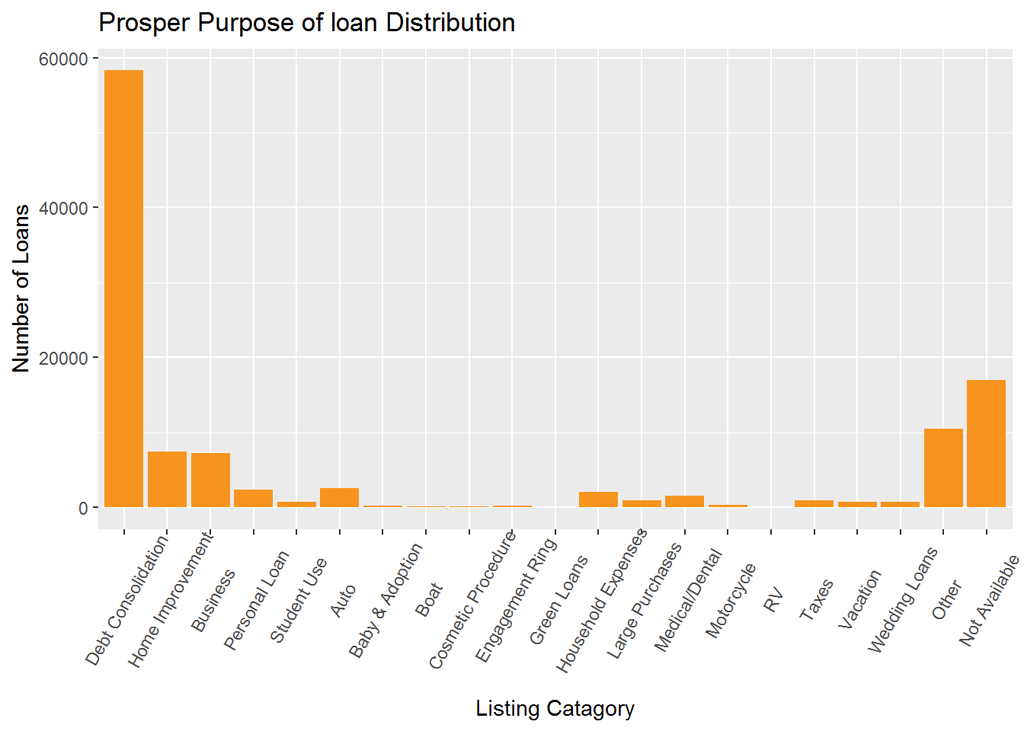

```
## Debt Consolidation   Home Improvement           Business
##              58308               7433               7189
##      Personal Loan        Student Use               Auto
##               2395                756               2572
##    Baby & Adoption               Boat Cosmetic Procedure
##                199                 85                 91
##    Engagement Ring        Green Loans Household Expenses
##                217                 59               1996
##    Large Purchases     Medical/Dental         Motorcycle
##                876               1522                304
##                 RV              Taxes           Vacation
##                 52                885                768
##      Wedding Loans              Other      Not Available
##                771              10494              16965
```

From this chart, we could see most people want money for debit consolidation, home improvement and business. Debit consolidation has a surprising amount which almost 50% of total number of loans. These data shows that most borrower already have their first job and is looking to pay their debt.

```
##              Cancelled             Chargedoff              Completed
##                      5                  11992                  38074
##                Current              Defaulted FinalPaymentInProgress
##                  56576                   5018                    205
##   Past Due (>120 days)   Past Due (1-15 days)  Past Due (16-30 days)
##                     16                    806                    265
##  Past Due (31-60 days)  Past Due (61-90 days) Past Due (91-120 days)
##                    363                    313                    304
```

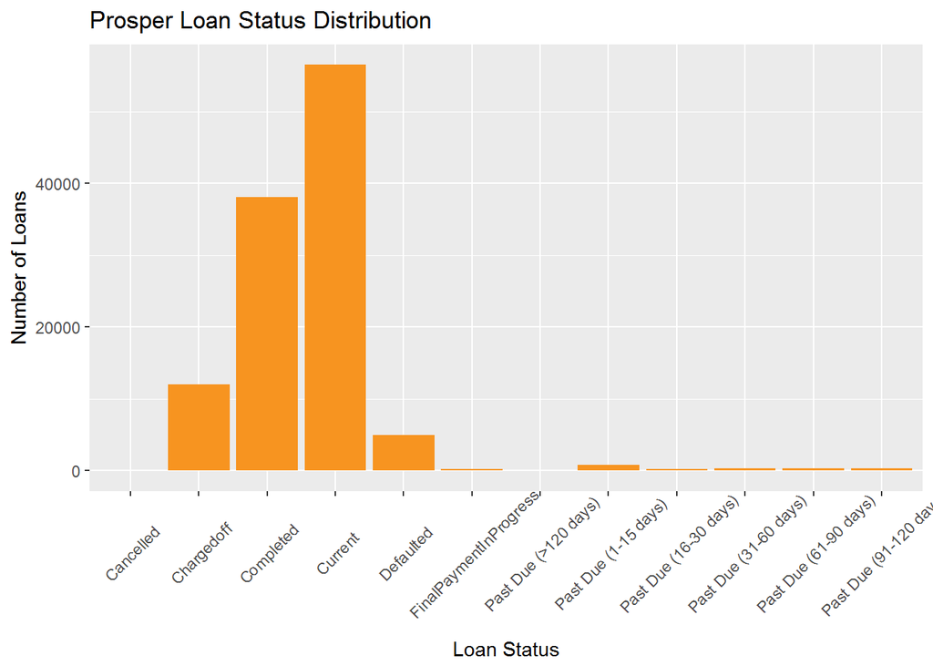

```
##          AK    AL    AR    AZ    CA    CO    CT    DC    DE    FL    GA
##  5515   200  1679   855  1901 14717  2210  1627   382   300  6720  5008
##    HI    IA    ID    IL    IN    KS    KY    LA    MA    MD    ME    MI
##   409   186   599  5921  2078  1062   983   954  2242  2821   101  3593
##    MN    MO    MS    MT    NC    ND    NE    NH    NJ    NM    NV    NY
##  2318  2615   787   330  3084    52   674   551  3097   472  1090  6729
##    OH    OK    OR    PA    RI    SC    SD    TN    TX    UT    VA    VT
##  4197   971  1817  2972   435  1122   189  1737  6842   877  3278   207
##    WA    WI    WV    WY
##  3048  1842   391   150
```

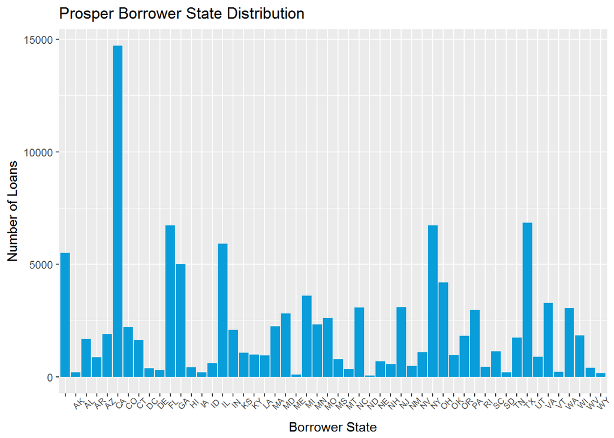

From this chart, we could see the top borrower is from “CA”, which is almost 15,000 borrowers. Other popular states are “FL”,“IL”,“NY” and “TX”.

```
##      Employed     Full-time     Part-time Self-employed       Retired
##         67322         26355          1088          6134           795
## Not available  Not employed        others                        NA's
##          5347           835             0             0          6061
```

[figure not shown]

Most borrowers are employed or had a full-time job. Surprisingly, there’re few part-time job borrowers. Probabaly because part-time job is not stable or do not have enough income to pay back the loan.

```
##    Min. 1st Qu.  Median    Mean 3rd Qu.    Max.    NA's
##   0.000   0.140   0.220   0.276   0.320  10.010    8554
```

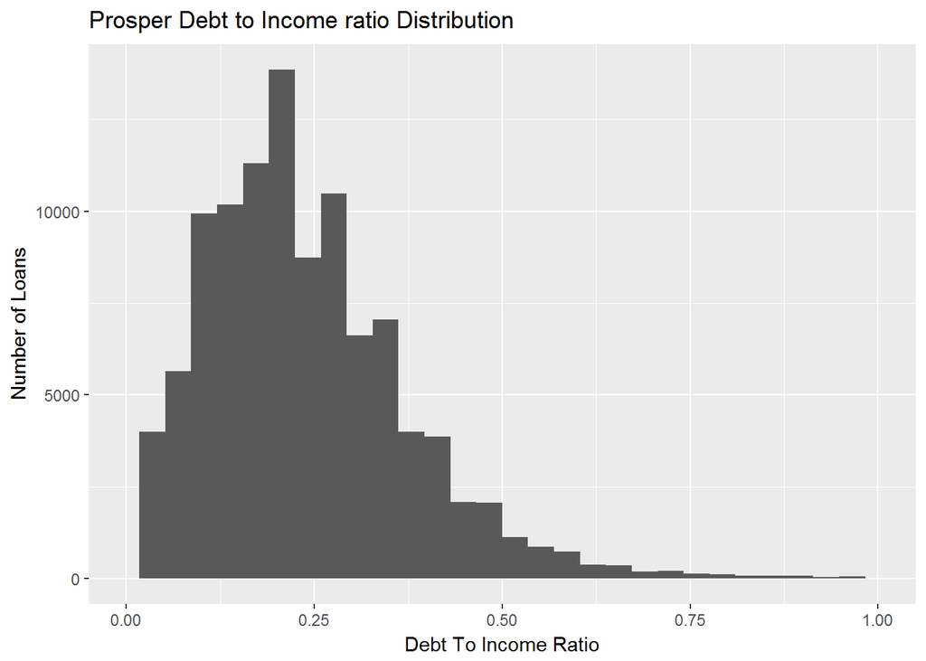

Most borrower’s debt to income ratio is between 0-0.6. The peak is around 0.23. However, there’re still some borrower’s ratio is above 0.75.

```
##                                                        Accountant/CPA
##                               3588                               3233
##           Administrative Assistant                            Analyst
##                               3688                               3602
##                          Architect                           Attorney
##                                213                               1046
##                          Biologist                         Bus Driver
##                                125                                316
##                         Car Dealer                            Chemist
##                                180                                145
##                      Civil Service                             Clergy
##                               1457                                196
##                           Clerical                Computer Programmer
##                               3164                               4478
##                       Construction                            Dentist
##                               1790                                 68
##                             Doctor                Engineer - Chemical
##                                494                                225
##              Engineer - Electrical              Engineer - Mechanical
##                               1125                               1406
##                          Executive                            Fireman
##                               4311                                422
##                   Flight Attendant                       Food Service
##                                123                               1123
##            Food Service Management                          Homemaker
##                               1239                                120
##                           Investor                              Judge
##                                214                                 22
##                            Laborer                        Landscaping
##                               1595                                236
##                 Medical Technician                  Military Enlisted
##                               1117                               1272
##                   Military Officer                       Nurse's Aide
##                                346                                491
##                        Nurse (LPN)                         Nurse (RN)
##                                492                               2489
##                              Other                         Pharmacist
##                              28617                                257
##         Pilot - Private/Commercial  Police Officer/Correction Officer
##                                199                               1578
```

[output cut: 13 more lines]

```
##                                741                                 41
## Student - College Graduate Student           Student - College Junior
##                                245                                112
##           Student - College Senior        Student - College Sophomore
##                                188                                 69
##        Student - Community College         Student - Technical School
##                                 28                                 16
##                            Teacher                     Teacher's Aide
##                               3759                                276
##              Tradesman - Carpenter            Tradesman - Electrician
##                                120                                477
##               Tradesman - Mechanic                Tradesman - Plumber
##                                951                                102
##                       Truck Driver                    Waiter/Waitress
##                               1675                                436
```

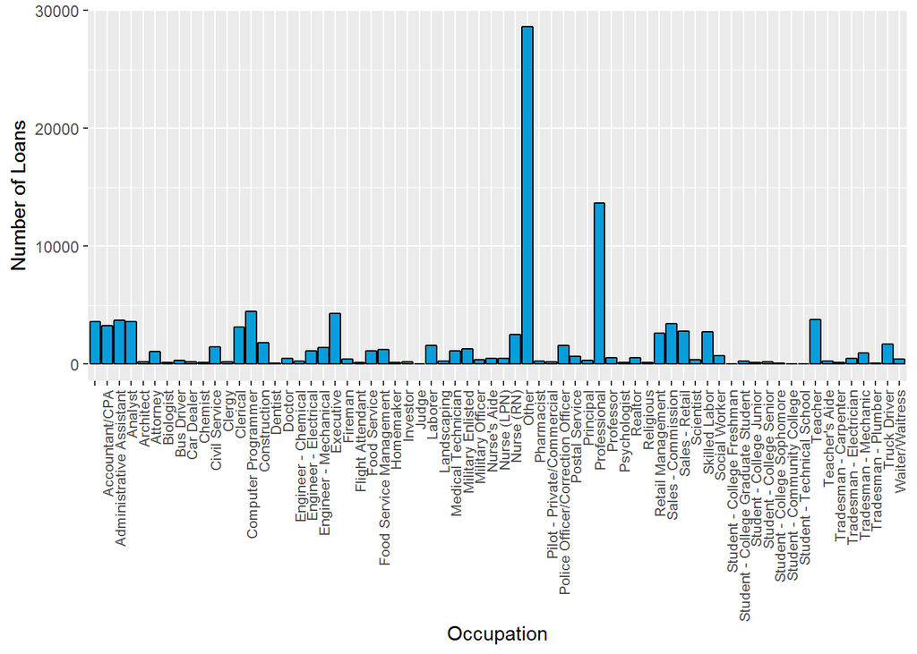

Here we can see borrowers are from all over of different industry. There are also many people choose “Other” or “professional” not sepcifying their occupation.

```
##    Min. 1st Qu.  Median    Mean 3rd Qu.    Max.    NA's
##     9.5   669.5   689.5   695.1   729.5   889.5     591
```

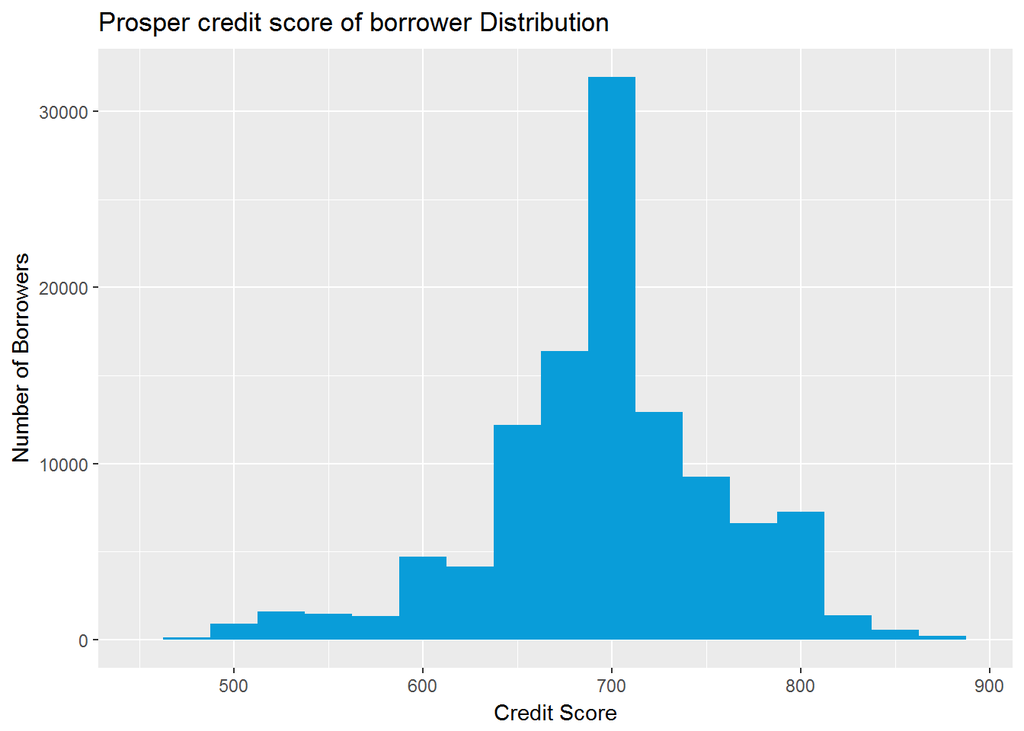

Here we could see a normal distribution chart. The main average of credit score from borrowers are around 700. Most borrowers are from 600-800.

```
##    Min. 1st Qu.  Median    Mean 3rd Qu.    Max.    NA's
##   0.000   0.000   0.000   4.155   3.000  99.000     990
```

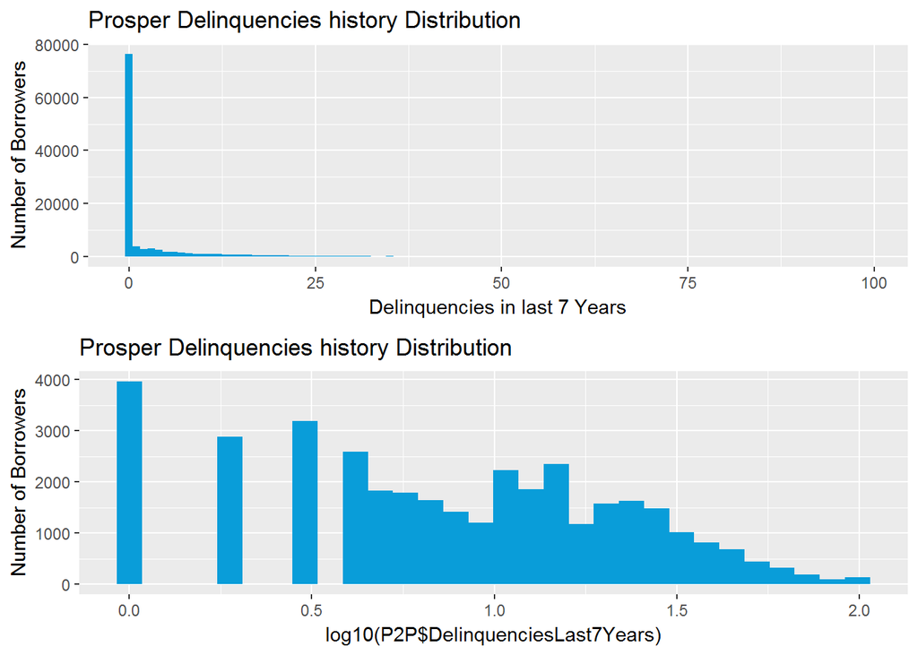

Here we could see a positive skewed chart and a log transformation chart. Most people do not have delinquency record. And people with few delinquency record can still get the loan.

```
##    Min. 1st Qu.  Median    Mean 3rd Qu.    Max.
##    1000    4000    6500    8337   12000   35000
```

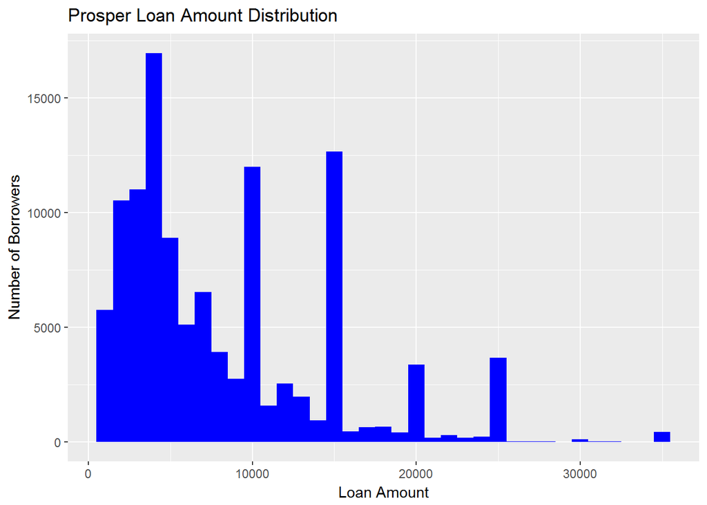

Here we can see main loan amount are $4000,$10000 and $15000. And minimum loan amount is $1000.

```
##    Min. 1st Qu.  Median    Mean 3rd Qu.    Max.
##   12.00   36.00   36.00   40.83   36.00   60.00
```

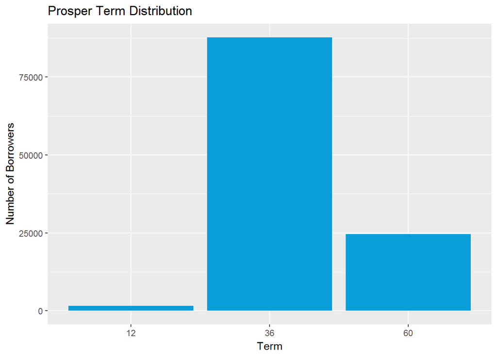

Based on chart and summary, we could see most people choose 36 months, then 60 months and last 12 months. 36 months loan is more than tirple of 60 months loan.

```
##    Min. 1st Qu.  Median    Mean 3rd Qu.    Max.
##     0.0   131.6   217.7   272.5   371.6  2252.0
```

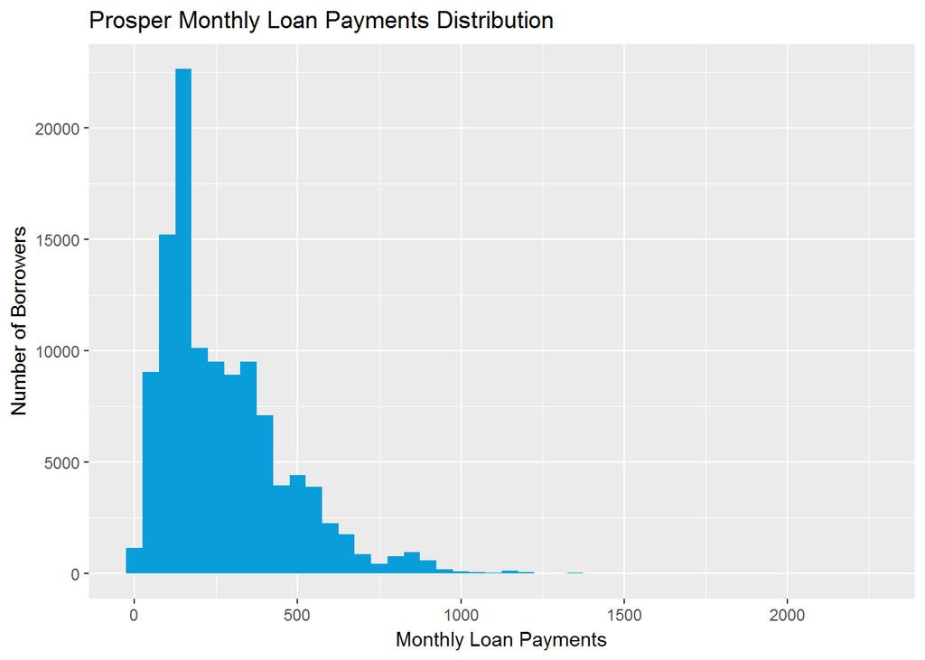

From this chart, we could see most borrower’s monthly loan payments are between $0-$500. Mean and median monthly loan payment is $272.50 and $217.70.

```
## False  True
## 56459 57478
```

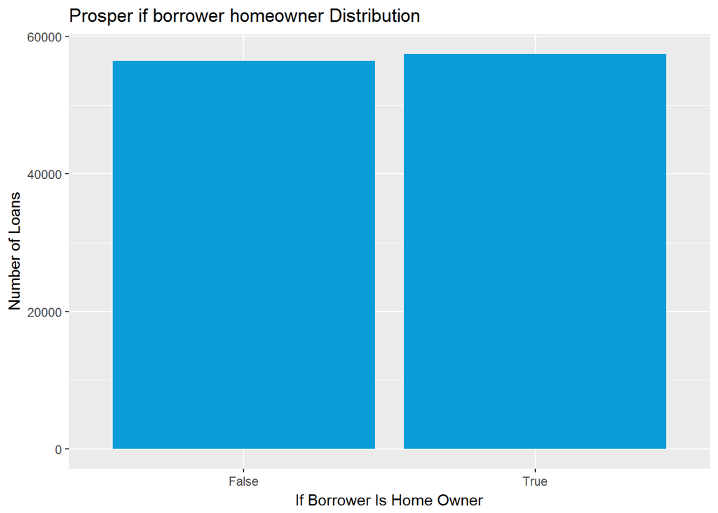

Here we could see almost half of borrower are homeowners and other half are not.

# Univariate Analysis

### What is/are the main feature(s) of interest in your dataset?

My main features of interest are: 1.Borrower rate. I am interested to know the relationship between borrower rate and other variables relationship. What factors will mostly affect borrower rate? Like prosper score,income range, loan amount etc. 2.Number of investors. I am interested to know which loans are more attractive for investing. What are the main characteristics of those loans?

### What other features in the dataset do you think will help support your investigation into your feature(s) of interest?

Other features could be creidt score, debt to income ratio, prosper rating, occupation and employment status.

### Did you create any new variables from existing variables in the dataset?

No, I did not

### Of the features you investigated, were there any unusual distributions? Did you perform any operations on the data to tidy, adjust, or change the form of the data? If so, why did you do this?

DUring my investigation, I find some unusuual distributions. When I do income range and job research, I find income lower than $25000 and part-time job borrowers are not main borrowers. I’m wodering if prosper set up any income limits for borrowers. I did not perform any operations on the data.

# Bivariate Plots Section

```
## P2P$ProsperRating..Alpha.: AA
##    Min. 1st Qu.  Median    Mean 3rd Qu.    Max.
## 0.04000 0.06990 0.07790 0.07912 0.08450 0.21000
## --------------------------------------------------------
## P2P$ProsperRating..Alpha.: A
##    Min. 1st Qu.  Median    Mean 3rd Qu.    Max.
##  0.0498  0.0990  0.1119  0.1129  0.1239  0.2150
## --------------------------------------------------------
## P2P$ProsperRating..Alpha.: B
##    Min. 1st Qu.  Median    Mean 3rd Qu.    Max.
##  0.0693  0.1414  0.1509  0.1545  0.1639  0.3500
## --------------------------------------------------------
## P2P$ProsperRating..Alpha.: C
##    Min. 1st Qu.  Median    Mean 3rd Qu.    Max.
##  0.0895  0.1765  0.1914  0.1944  0.2099  0.3500
## --------------------------------------------------------
## P2P$ProsperRating..Alpha.: D
##    Min. 1st Qu.  Median    Mean 3rd Qu.    Max.
##  0.1157  0.2287  0.2492  0.2464  0.2625  0.3500
## --------------------------------------------------------
## P2P$ProsperRating..Alpha.: E
##    Min. 1st Qu.  Median    Mean 3rd Qu.    Max.
##  0.1479  0.2712  0.2925  0.2933  0.3149  0.3600
## --------------------------------------------------------
## P2P$ProsperRating..Alpha.: HR
##    Min. 1st Qu.  Median    Mean 3rd Qu.    Max.
##  0.1779  0.3134  0.3177  0.3173  0.3177  0.3600
## --------------------------------------------------------
## P2P$ProsperRating..Alpha.:
## NULL
```

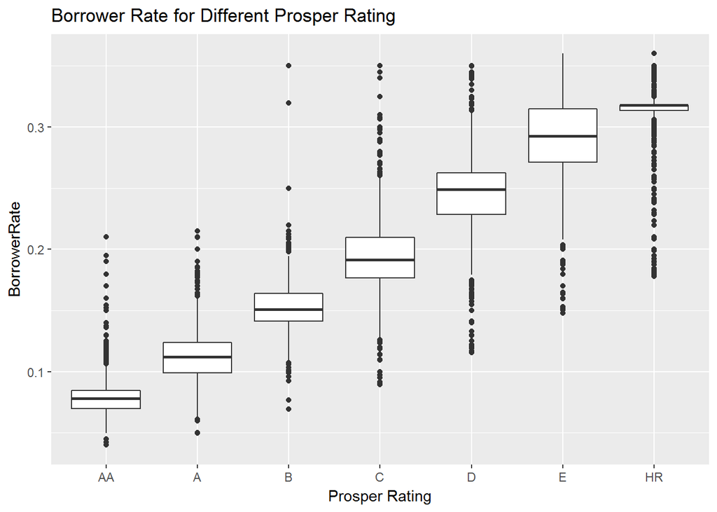

From this chart, we could see the reversed relationship between borrower rate and prosper rating. The higher prosper rating, the lower borrower rate.

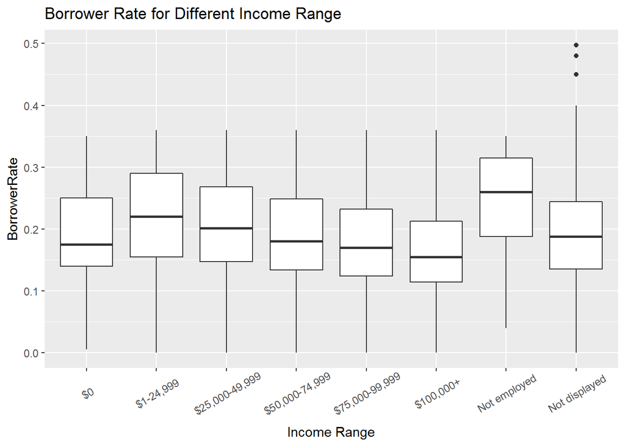

It looks like borrower with higher income will get lower borrower rate.

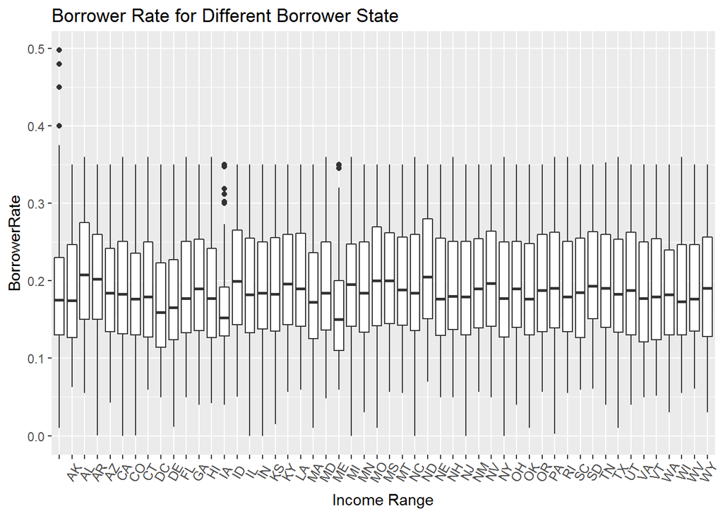

From this chart, we could see borrower rate has not a strong relationship with borrower state.

```
##
##   (0,300] (300,600] (600,900]
##       133      6632    106581
```

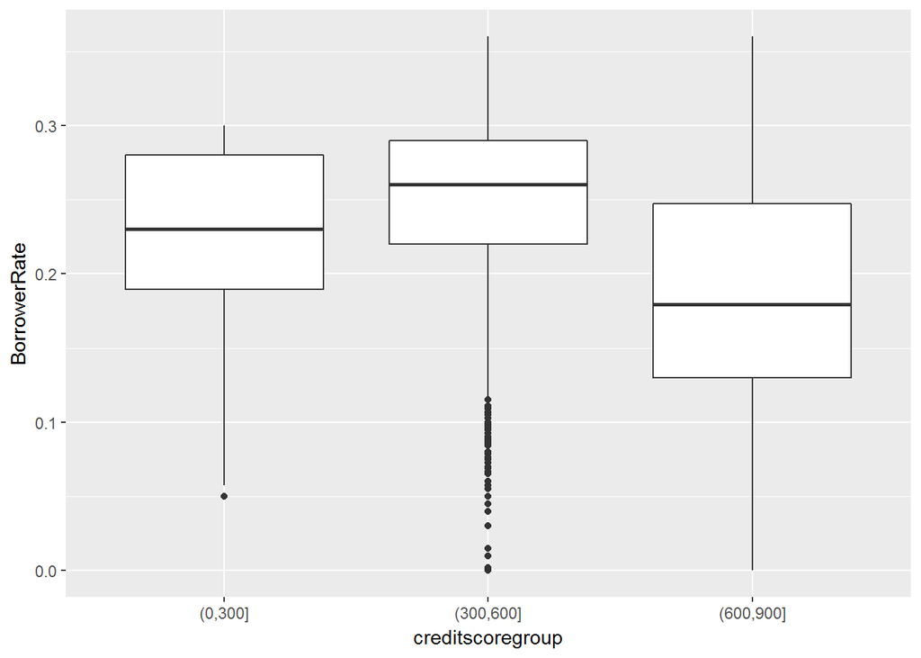

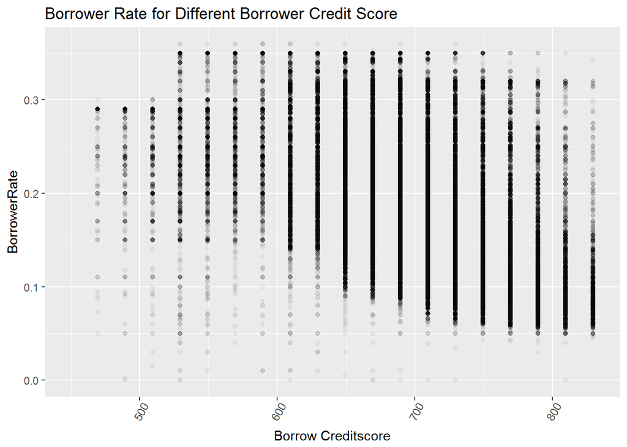

Here we use two charts to explore the realtionship between borrower credit score and borrower rate. From first chart, we could see the relationship between different credit score group and borrower rate. Borrower with 600-900 credit score has lowest borrower rate, which average is arount 0.18. From second chart, we could see a scotter plot chart with borrower’s credit score 500 or above. We could clearly see that the higher credit score, the lower borrower rate.

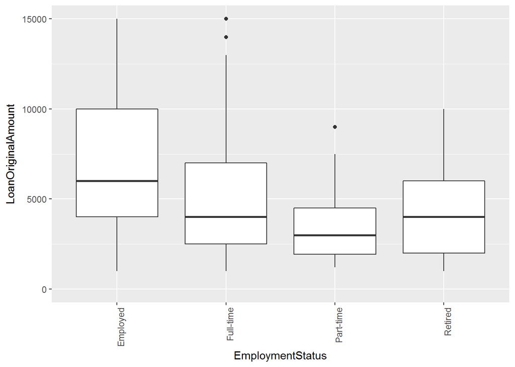

Employed and retired borrower seems to have higher loan amount than part-time.

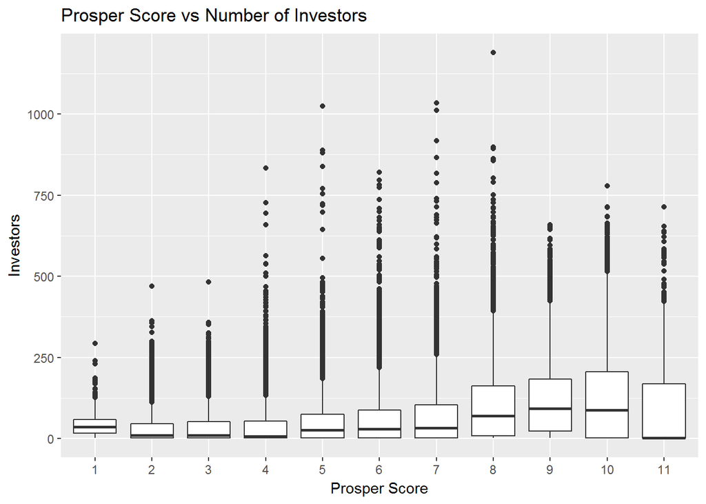

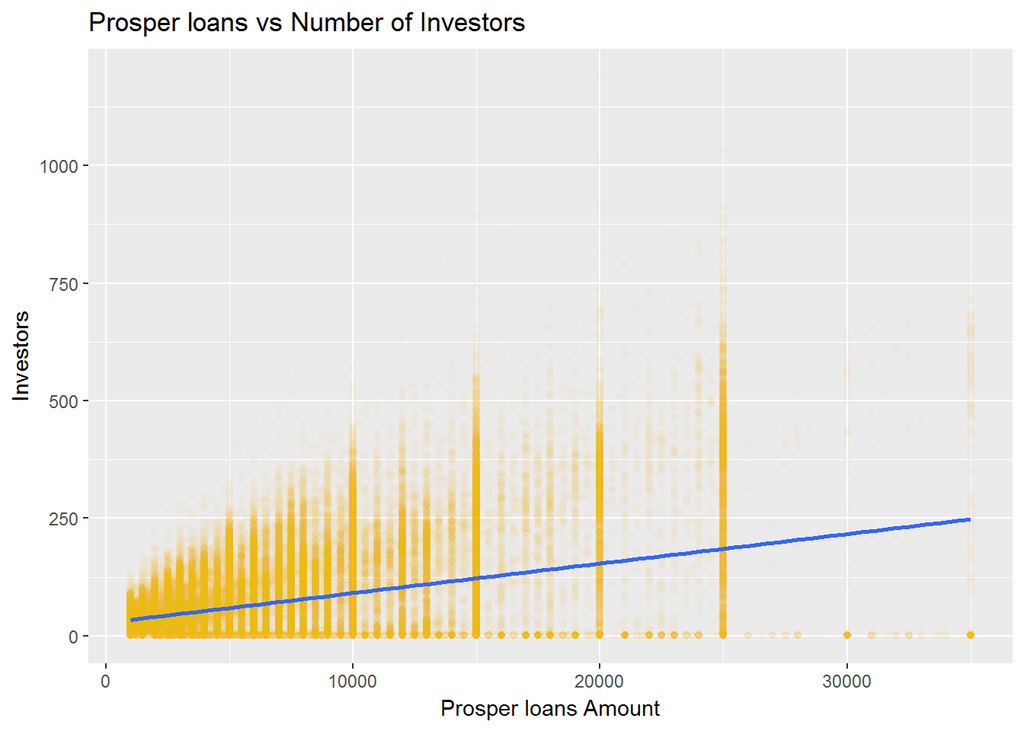

Here we could see that the higher loans amount, the more investors.

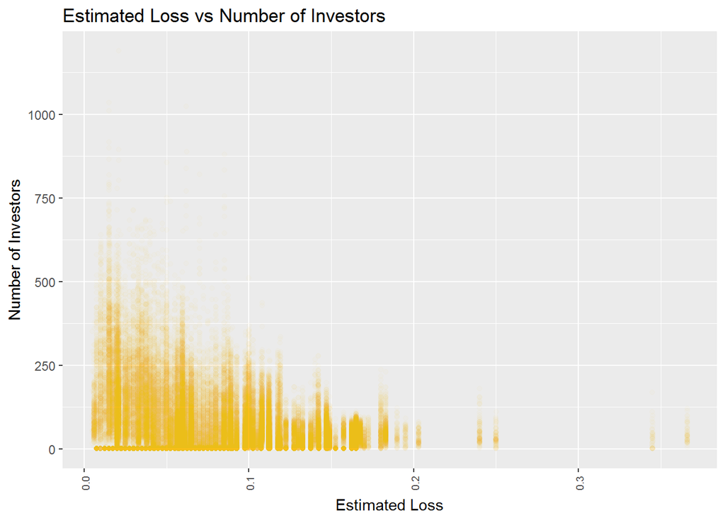

We can found the lower the estmated loss, the more investors.

# Bivariate Analysis

### Did you observe any interesting relationships between the other features (not the main feature(s) of interest)?

No

### What was the strongest relationship you found?

The reverse relationship between borrower rate and prosper rating.

# Multivariate Plots Section

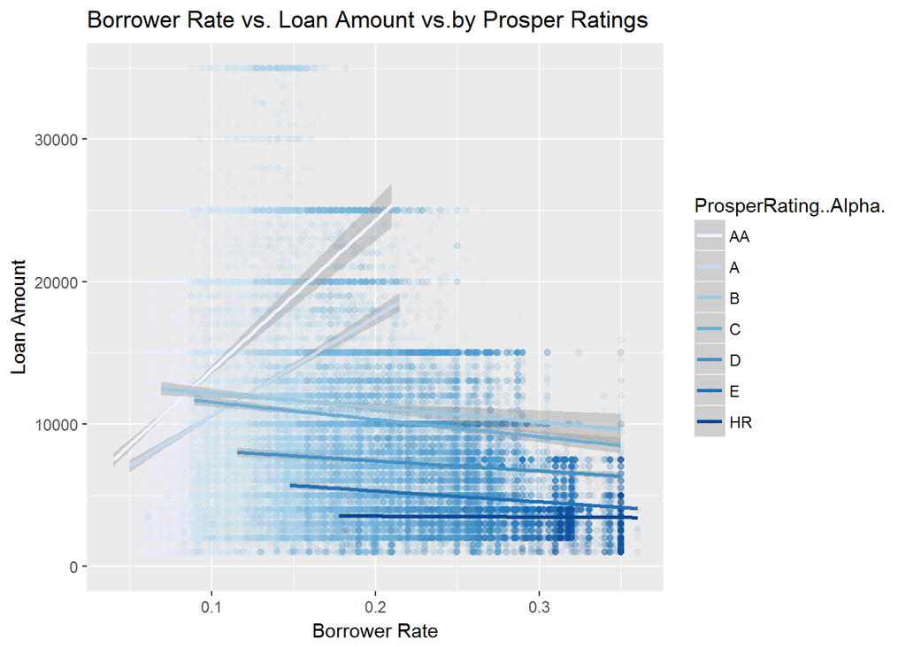

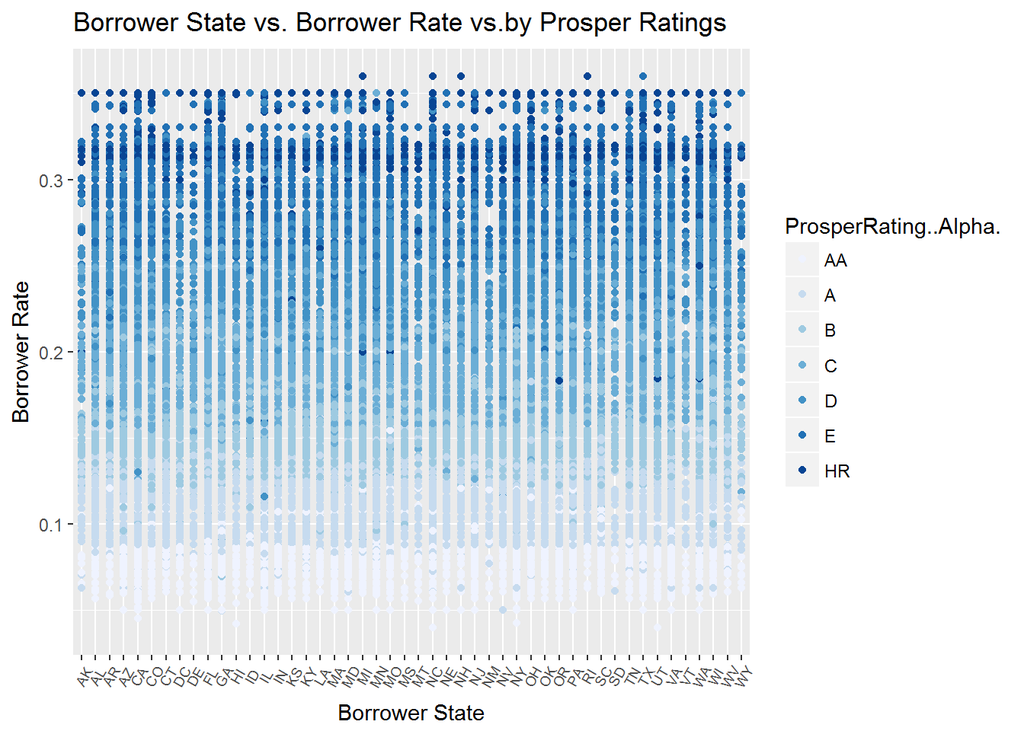

Each state is almost same, but still the lower the prosper rating, the higher borrower rate.

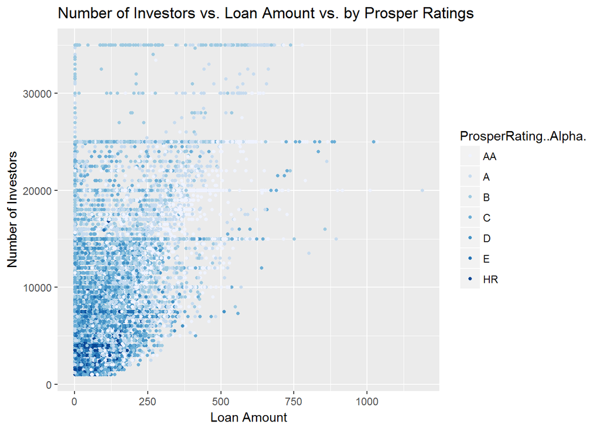

From this chart, we could see the relationship between Investors, loan amount and prosper ratings. The higher the prosper ratings, there will be more investors. However, most investors are interested in loan amount less than $30,000. $10,000 to $20,000 are most popular investor’s choice no matter what rating.

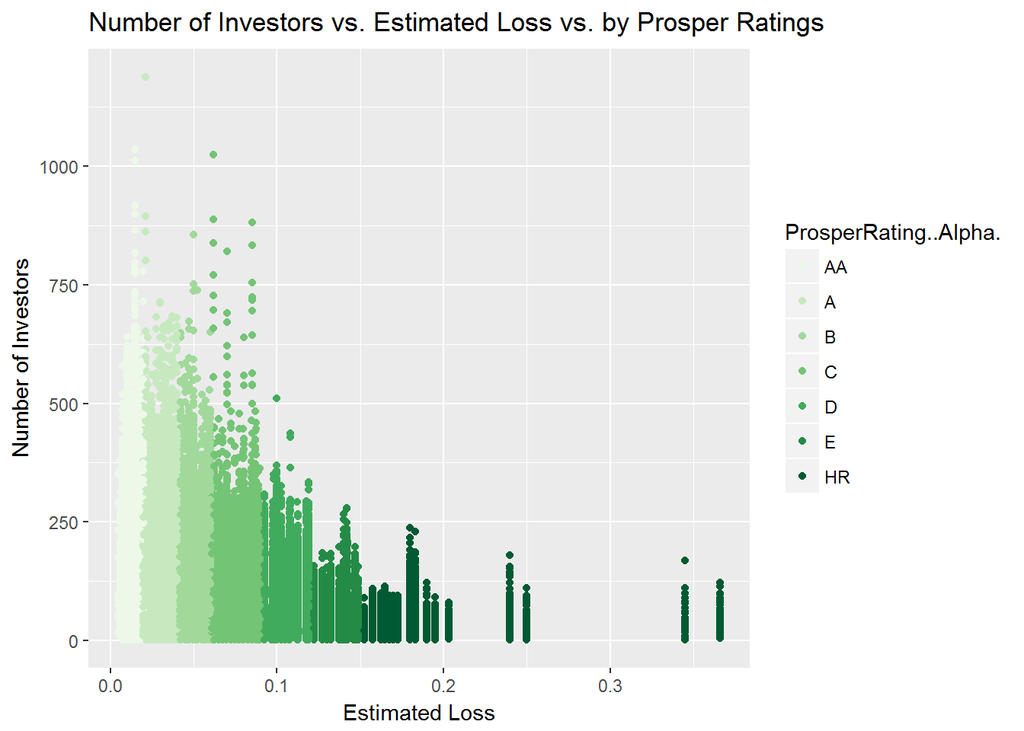

The higher the prosper rating, the lower the estimated loss, the more the number of investors.

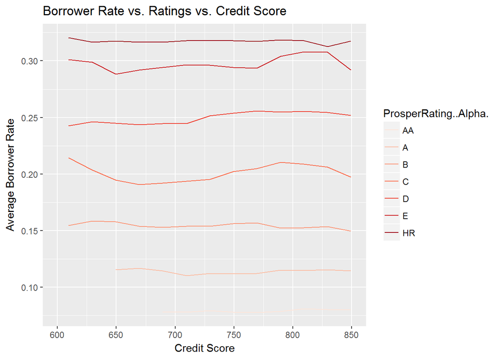

This chart summrize the relationship between borrower rate, rating and borrower credit score. We can see loans with high rating usually require higher credit score.

# Multivariate Analysis

### Talk about some of the relationships you observed in this part of the investigation. Were there features that strengthened each other in terms of looking at your feature(s) of interest?

Prosper rating and investors are strong correlated. Here we can see prosper rating, investors, loan amount and estimated loss are affecting each other.

### OPTIONAL: Did you create any models with your dataset? Discuss the strengths and limitations of your model.

No

# Final Plots and Summary

### Plot One

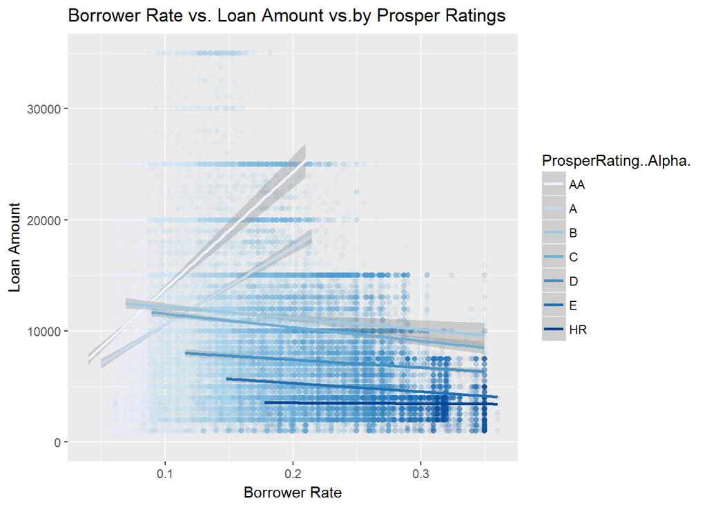

### Description One

This chart basically summarize the realtionship betwwen borrower rate, loan amount and prosper ratings. We can clearly see that high rating loans usually got low borrower rate. And some large loan amount (more than $25,000) are only available for high rating loans. And we also can see loans with higher borrower rate and lower rating usually has small loan amount.

### Plot Two

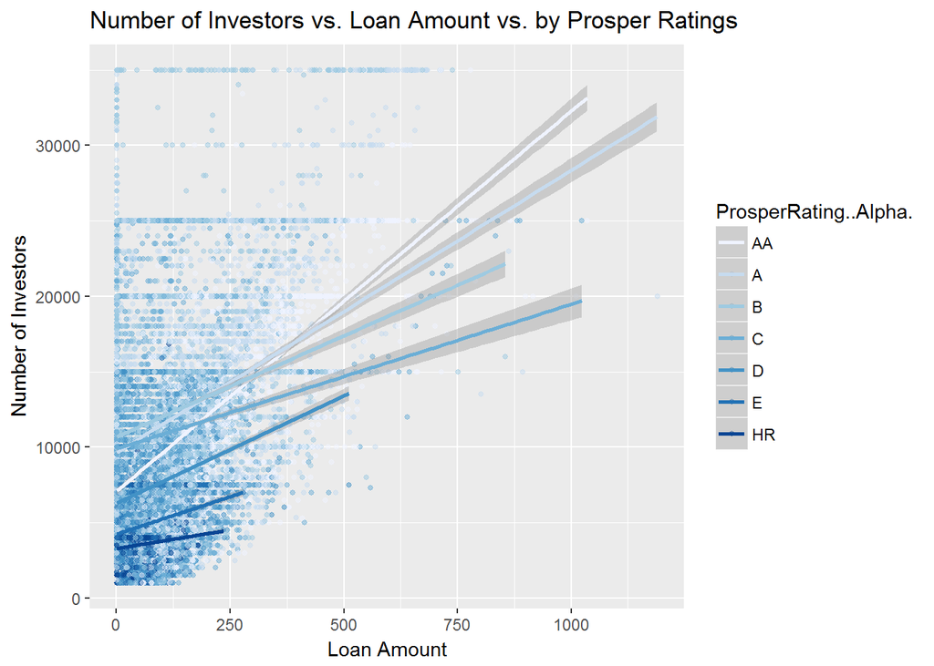

### Description Two

This chart summrize the relationship between number of investors, loan amount and prosper ratings. We can see most investors are interested in investing loan amount less than $25,000. For loans above $25,000, investors are Only interested in high rating loans, like “A” or “AA”. When investors was interested on low rating loans, they only invest loans with smaller loan amount(less than $15,000). Probaly they are worried about risk with large loan amount.

### Plot Three

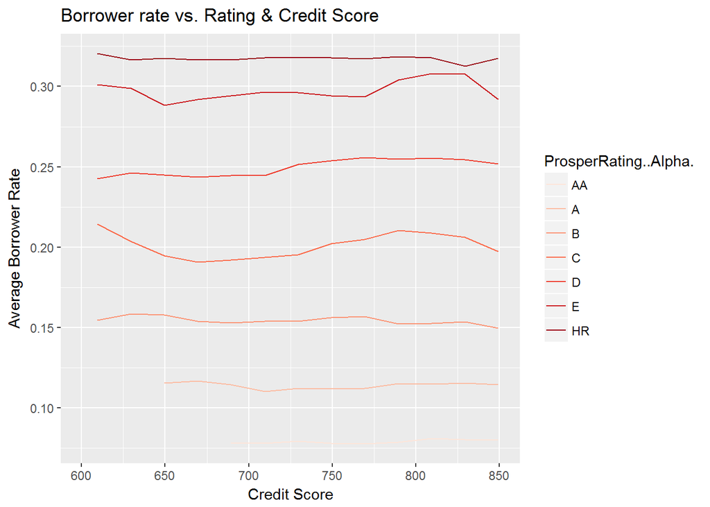

# Reflection

I used to be an Investment Consultant for more than 6 years, so I had some general ideas about loans and investments. So I choose this database as my research topic. After I reviewed the dataset, I was interested to find the relationship between loan rating, borrower rate and number of investors. I wanted to learn more about P2P company and see what factors will affect investors to make their decisions.

I was new to computer system. So at the beginning, I was struggling with ggplot2 syntax. After lots of practise, reserching, reading and learning on Google, I gradually become comfortable with ggplot2 sytax. Before I did this project, I did not learn deeply about P2P company like Prosper.com. But, this topic was quite interesting to me and related to my previous job. I also checked Prosper.com to see the meaning of each column and how they operate their business. I also took time to read database and wanted to find most related factors.

Then I imported the databased and used the ggplot2 to see the correlation with each factors and variables. After I did two variable comprison and three variable comprison, I finlly find the relationship between borrower rate, number of investors, ratings, creidt socre and loan amount. I think these are important factors which will most affect the profit of the loan.

After I finished my project, I got some future ideas about this database.When I do the quick reserch, I realized that there was a global financial crisis in 2008, but it was not obvious on these database. So if I will continue to do future work on this dataset, I will split the timeframe between 2004-2009 and 2009-2014 to see if there was any financial pressure or effects on number of borrowers, borrower rate and number of investors.